# dataviz-project-YZ

# Graph 3: Alcohol Consumption in different Schools

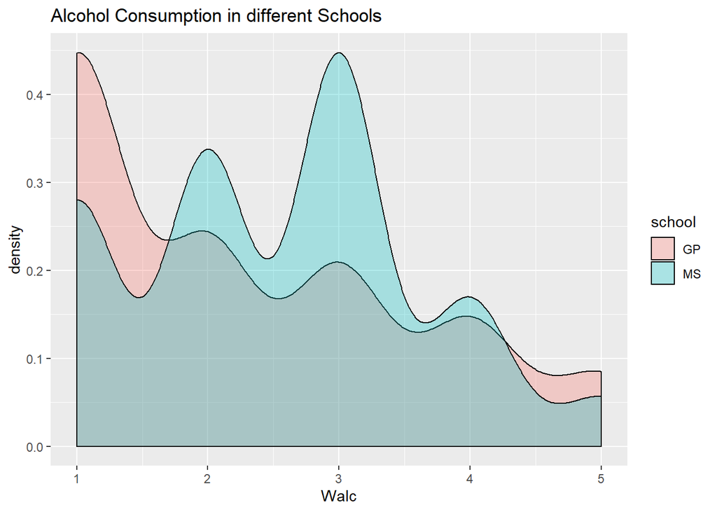

```r
ggplot(data = salc, mapping = aes(x = Walc, fill=school)) +
geom_density(alpha=0.3, adjust = 1) +
ggtitle("Alcohol Consumption in different Schools")
```

The density graph of the students’ alcohol consumtion within the two schools tells us that students in MS generally consume more alcohol than those in GP. Also, GP has more students with little alcohol consumption. From graph 1, we’ve learned that students in GP generally have higher academic achivements. This drives to the conclusion that drinking does negatively affect students’ academic performance. Thus, school contributed significantly to the variation in drinking among students and played an important role in predicting alcohol consumption among its students.